# Multilevel Modelling – Practical 1 (Week 2)

## Instructions – start here!

The first part of this notebook (**Exercise 1**) takes you through a simple linear regression (using simulated data).

The second part of the notebook (**Exercise 2**) involves a multiple linear regression analysis of hourly wage data.

## Exercises 1

Copy and paste the following code chunk which generates pairs $(x_1,y_1), (x_2,y_2),\ldots,(x_n,y_n)$ where $n=200$.

```r
set.seed(43515) # for reproducibility
n <- 200
x <- rnorm(n)
y <- 2+3*x+rnorm(n,0,1)
```

We can visualise the data with a scatterplot:

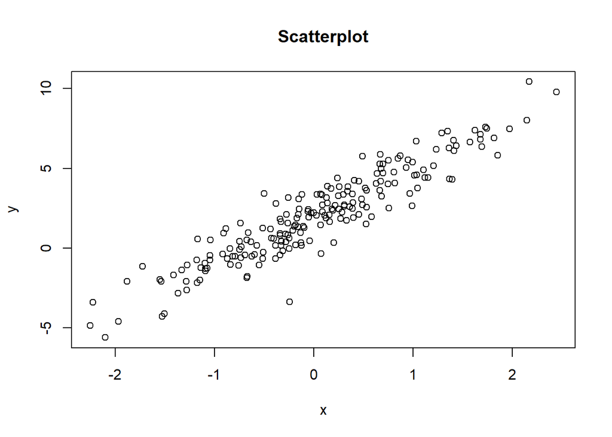

```r
plot(x,y,main="Scatterplot")
```

1. What distribution are the $x$ and $y$ values simulated from? Do histograms of $x$ and $y$ values match your answer?

**Click for solution**

Let $X$ and $Y$ be the random variables that the $x$ and $y$ values are simulations of (respectively). We have that $X\sim N(0,1)$ and $Y|X=x \sim N(2+3x,1)$. Hence $Y\sim N(2,3^2+1^2)\equiv N(2,10)$.

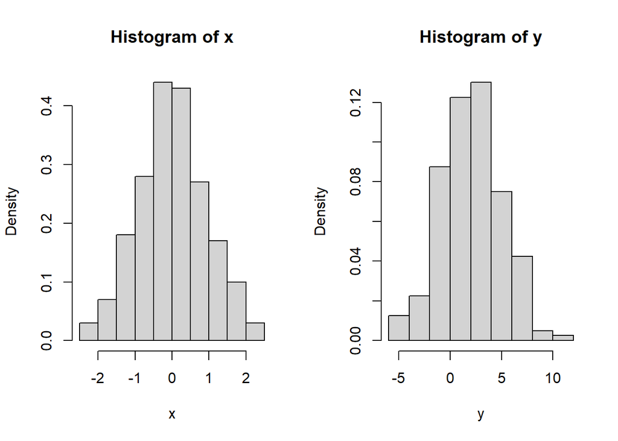

```r
par(mfrow=c(1,2))
hist(x,freq=FALSE)
hist(y,freq=FALSE)
```

Histograms are symmetric about 0 and 2, with most values between $-3$ and $+3$ (mean plus/minus 3 standard deviations) for $x$, and between $-7$ and $+11$ for $y$ (mean plus/minus roughly 3 standard deviations).

2. Calculate the Pearson correlation coefficient. How does this compare to the theoretical correlation? (Hint: recall that $Cov(X,a+bX)=Cov(X,a)+Cov(X,bX)=bCov(X,X)=bVar(X)$ for constants $a$ and $b$.)

**Click for solution**

```r
(r.pearson <- cor(x,y))
```

```
## [1] 0.9310128
```

The theoretical covariance is $Cov(X,Y)=Cov(X,2+3X)=3Var(X)=3$. Hence, the theoretical correlation between $X$ and $Y$ is $3/\sqrt{Var(X)Var(Y)}=3/ \sqrt{10}=0.95$.

We can fit a linear regression model to these data and summarise the output via

```r
model <- lm(y~x)
summary(model)
```

```
##
## Call:
## lm(formula = y ~ x)
##
## Residuals:
##     Min      1Q  Median      3Q     Max
## -4.6323 -0.6375 -0.0632  0.6329  2.9024
##
## Coefficients:
##             Estimate Std. Error t value Pr(>|t|)
## (Intercept)  1.99094    0.07455   26.71   <2e-16 ***
## x            2.92914    0.08161   35.89   <2e-16 ***
## ---
## Signif. codes:  0 '***' 0.001 '**' 0.01 '*' 0.05 '.' 0.1 ' ' 1
##
## Residual standard error: 1.054 on 198 degrees of freedom
## Multiple R-squared:  0.8668, Adjusted R-squared:  0.8661
## F-statistic:  1288 on 1 and 198 DF,  p-value: < 2.2e-16
```

3. Interpret this output. (At least three comments expected here!)

**Click for solution**

- The estimates of the intercept $b_0$ and slope $b_1$ are in agreement with the ground truth values that generated the data ($\beta_0=2$, $\beta_1=3$).
- Unsurprisingly, the t-test of the null hypothesis that $H_0:\beta_1=0$ suggests strong evidence against the null: it appears that the slope is needed. The F-test gives the same conclusion.
- The coefficient of determination is $R^2=0.8668$ suggesting that almost 90% of the variation in $Y$ is being explained by the regression on $x$. Note that

```r
(r.pearson^2)
```

```
## [1] 0.8667848
```

gives $R^2$.

4. Reproduce the scatterplot and overlay the regression line. (Hint: recall the `abline()` function and note that `coef(model)` gives the estimated intercept and slope.)

**Click for solution**

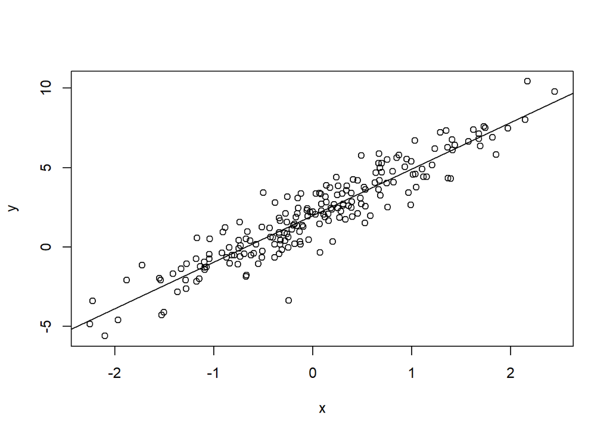

```r
plot(x,y)
abline(coef(model))
```

In what follows, it will be helpful to work with sorted (in increasing order) values of $x$ and the associated values of $y$. Hence execute the following code (and try to understand it):

```r
ind <- sort(x,index.return=TRUE)
x <- x[ind$ix]
y <- y[ind$ix]
model <- lm(y~x)
```

Recall that the `predict()` function can be used to generate fitted values $\hat{y}_i$, confidence and prediction intervals. The following code generates fitted values and the lower / upper limits of a 95% confidence interval for the mean response $\beta_0+\beta_1 x_i$:

```r
fit.y <- predict(model,newdata = data.frame(x),interval = "confidence")
head(fit.y) #inspect first few rows
```

```
##         fit       lwr       upr
## 1 -4.607650 -5.003545 -4.211755
## 2 -4.527100 -4.918888 -4.135311
## 3 -4.161157 -4.534383 -3.787930
## 4 -3.768590 -4.122093 -3.415088
## 5 -3.516371 -3.857319 -3.175424
## 6 -3.055568 -3.373856 -2.737279
```

5. Overlay (in red) on your plot from part 4 the 95% confidence interval for the expected response $\beta_0+\beta_1 x_i$ for each $x_i$. (Hint: `lines()` will be useful here.)

**Click for solution**

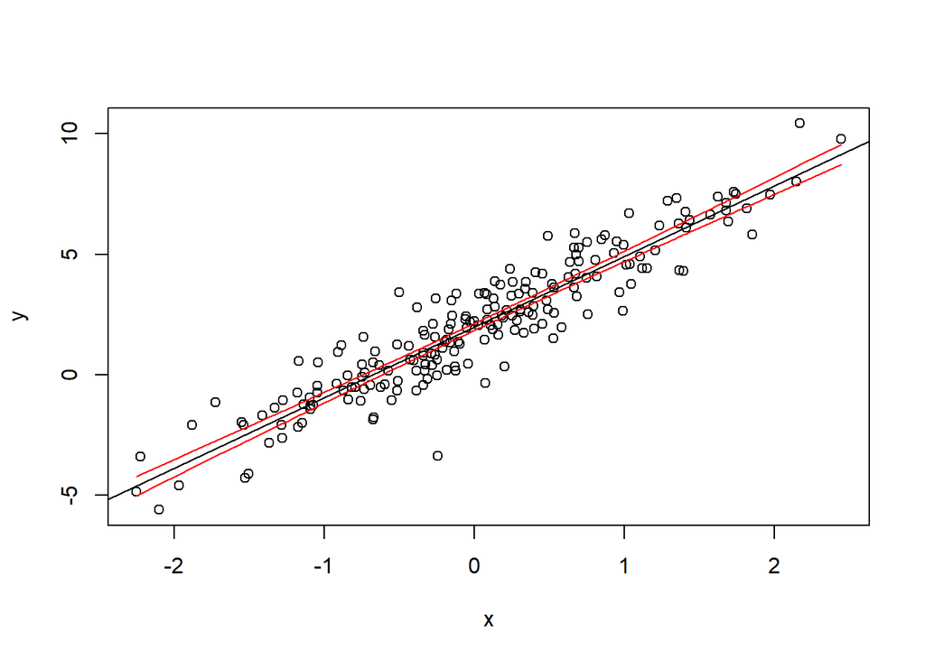

```r
plot(x,y)
abline(coef(model))
lines(x,fit.y[,2],type="l",col="red")
lines(x,fit.y[,3],type="l",col="red")
```

6. By using the `predict()` function with `interval = "prediction"`, overlay (in green) on your plot from part 5 the 95% prediction interval for each $y_i$. Comment.

**Click for solution**

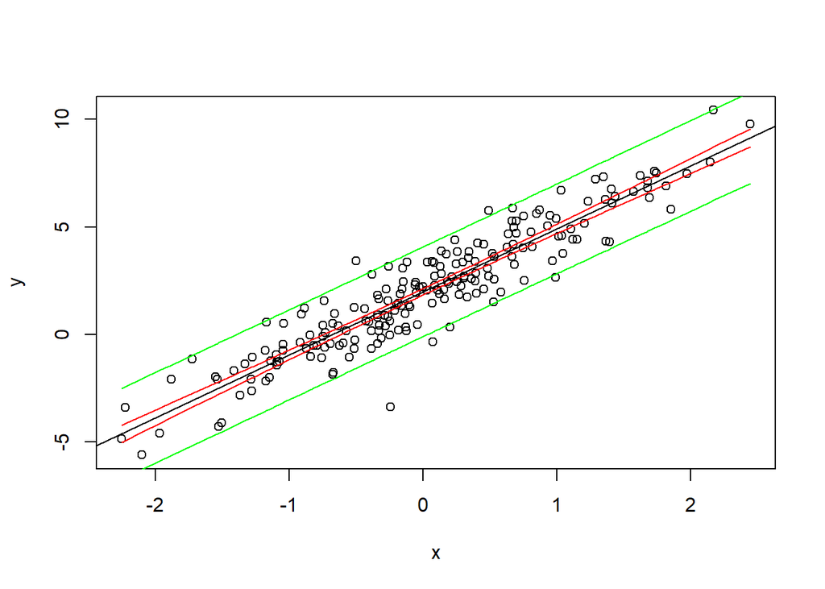

```r
fit.yp <- predict(model,newdata = data.frame(x),interval = "prediction")
plot(x,y)
abline(coef(model))
lines(x,fit.y[,2],type="l",col="red")
lines(x,fit.y[,3],type="l",col="red")
lines(x,fit.yp[,2],type="l",col="green")
lines(x,fit.yp[,3],type="l",col="green")
```

The prediction interval is wider than the confidence interval, as expected (recall that the prediction interval takes into account the variance of the error term).

7. Check the regression assumptions of `model`.

**Click for solution**

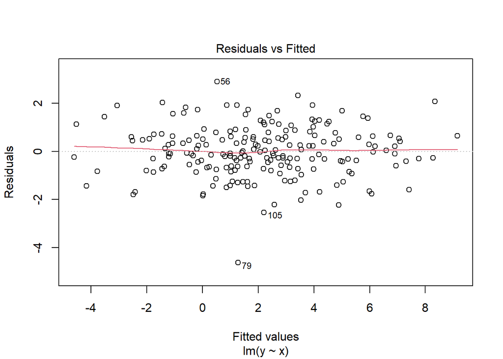

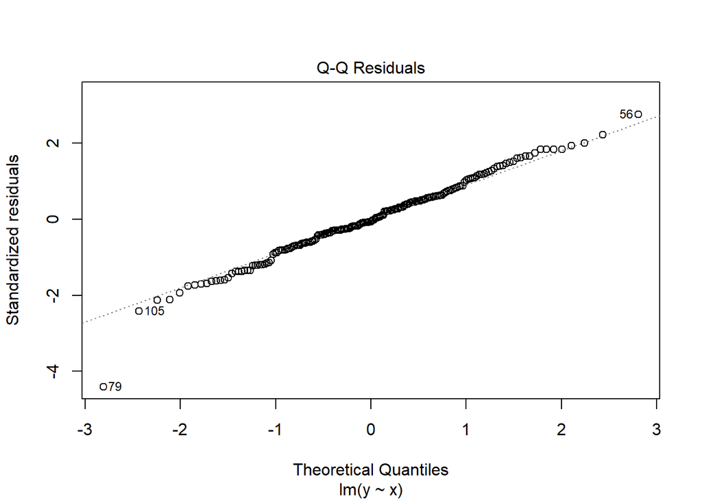

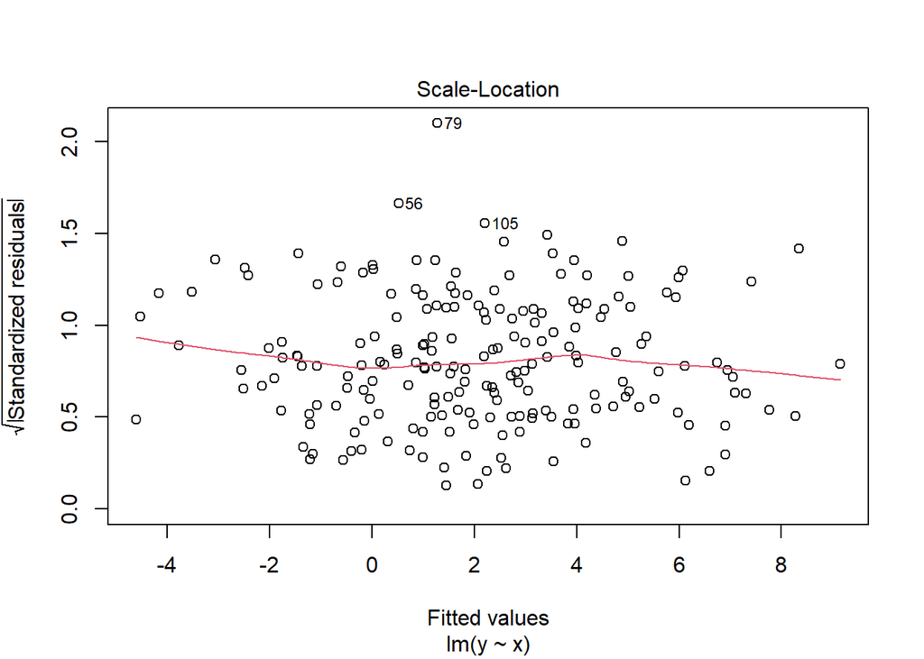

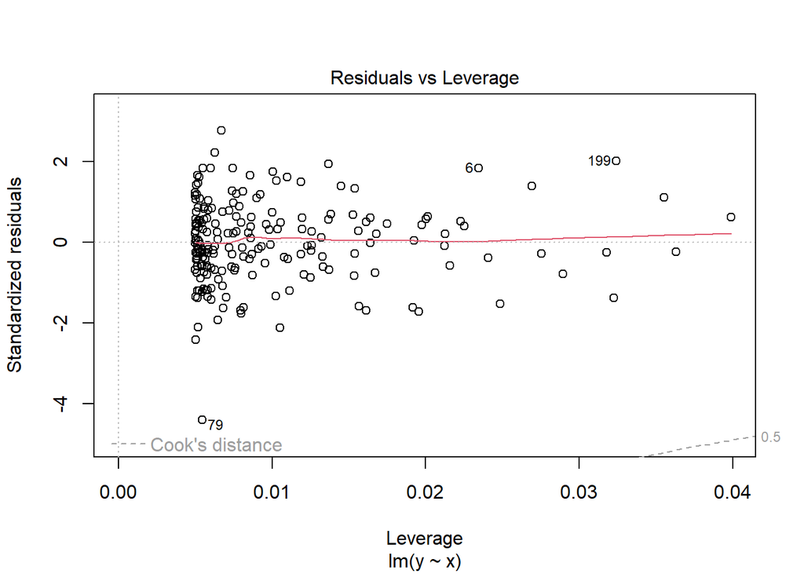

```r
plot(model)
```

The Q-Q plots suggests that the normality assumption is reasonable. Plots of the residuals against fitted values show no obvious pattern (i.e. no fanning out; the constant variance assumption appears reasonable, and no systematic shape; the linear relationship between response and predictors appears reasonable). The last plot indicates some outliers but these do not appear to be highly influential (according to Cook’s distance) so it is not necessary to remove them. All of these comments are as expected since we’ve simulated the data from a simpler linear regression model so we’d be surprised if it didn’t fit well!

8. Let’s add an outlying data point to our synthetic data set and look at the resulting scatter plot:

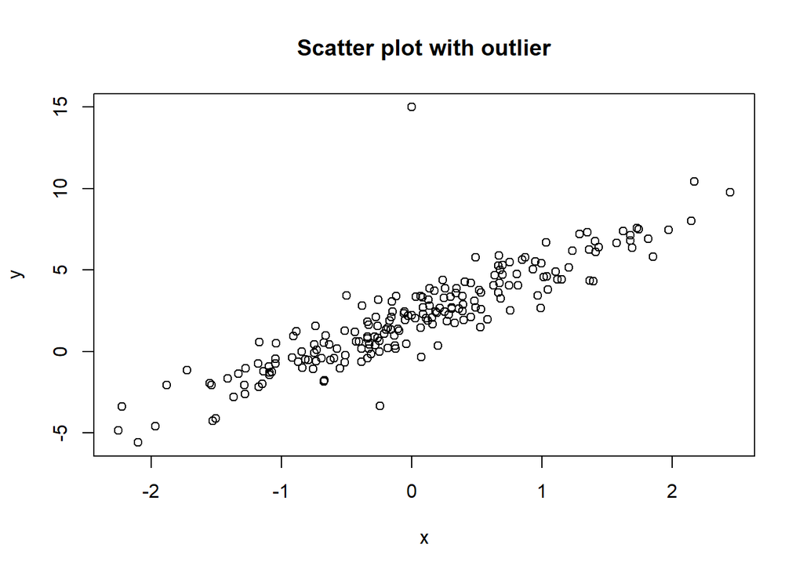

```r
x <- c(x,0)
y <- c(y, 15)
plot(x,y,main="Scatter plot with outlier")
```

Fit the simple regression model again (call it `model_out1`) and check the assumptions. What do you notice?

**Click for solution**

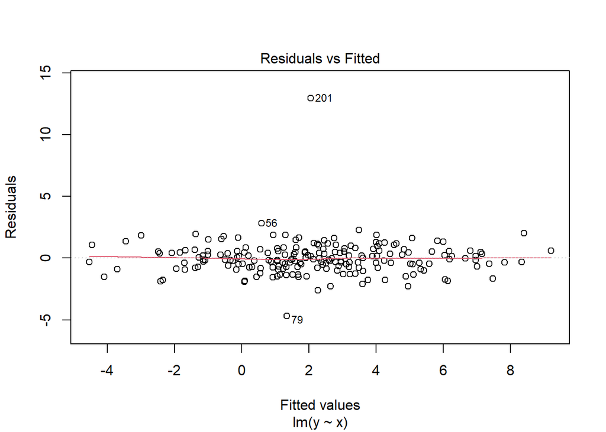

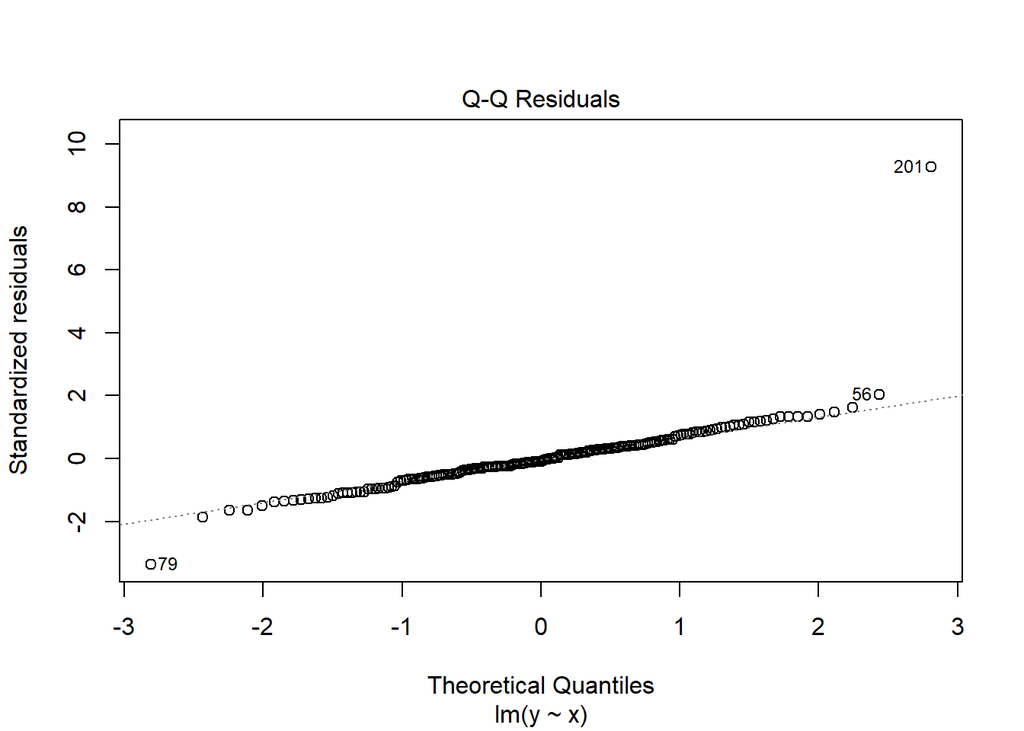

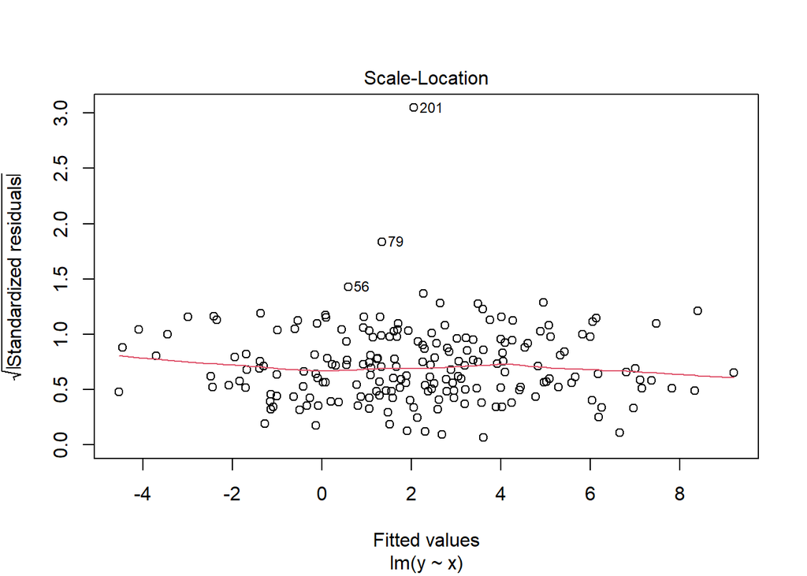

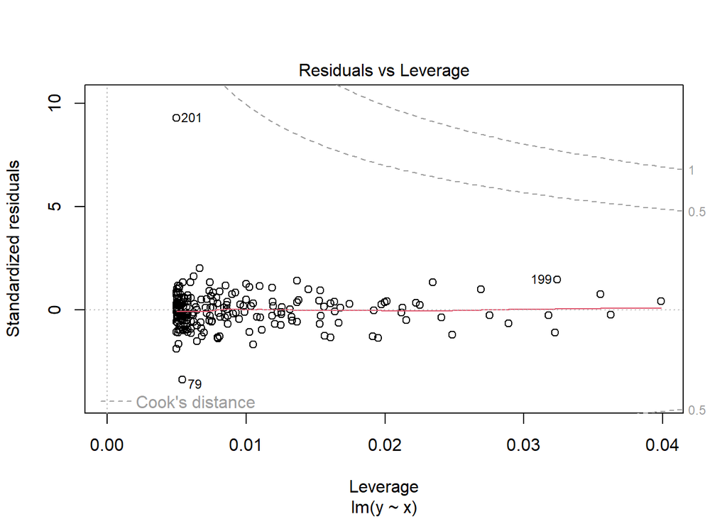

```r
model_out1 <- lm(y~x)
plot(model_out1)
```

The assumptions look reasonable. The outlier is not influential (Cook’s distance is less than 1 for the outlier). In fact, we can see that the outlier appears to have almost no affect on the line of best fit, whether it’s included or not.

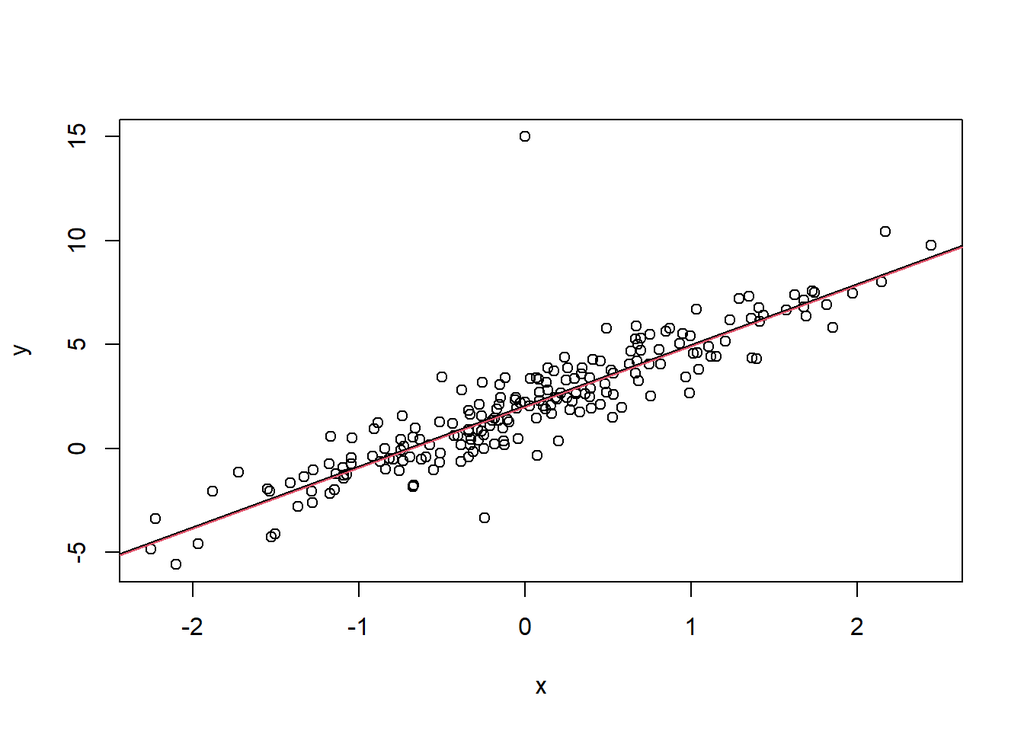

```r
plot(x,y)
abline(coef(model_out1))
abline(coef(model),col=2) #least squares line without the outlier
```

9. Let’s add another outlying data point to our synthetic data set and look at the resulting scatter plot:

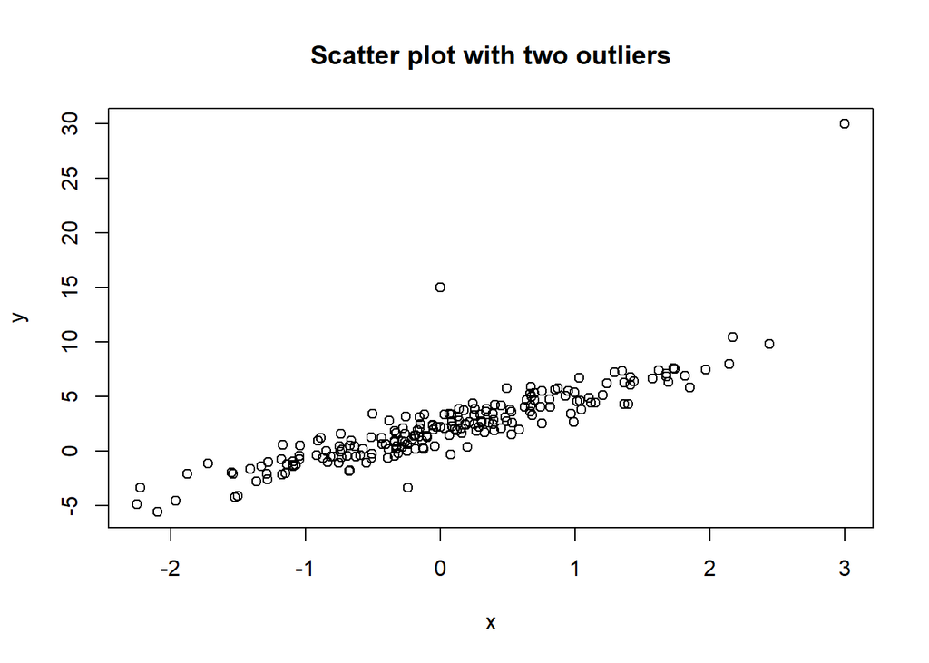

```r
x <- c(x,3)
y <- c(y, 30)
plot(x,y,main="Scatter plot with two outliers")
```

Fit the simple regression model again (call it `model_out2`) and check the assumptions. What do you notice?

**Click for solution**

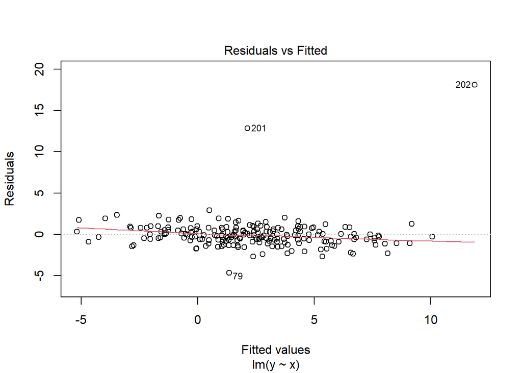

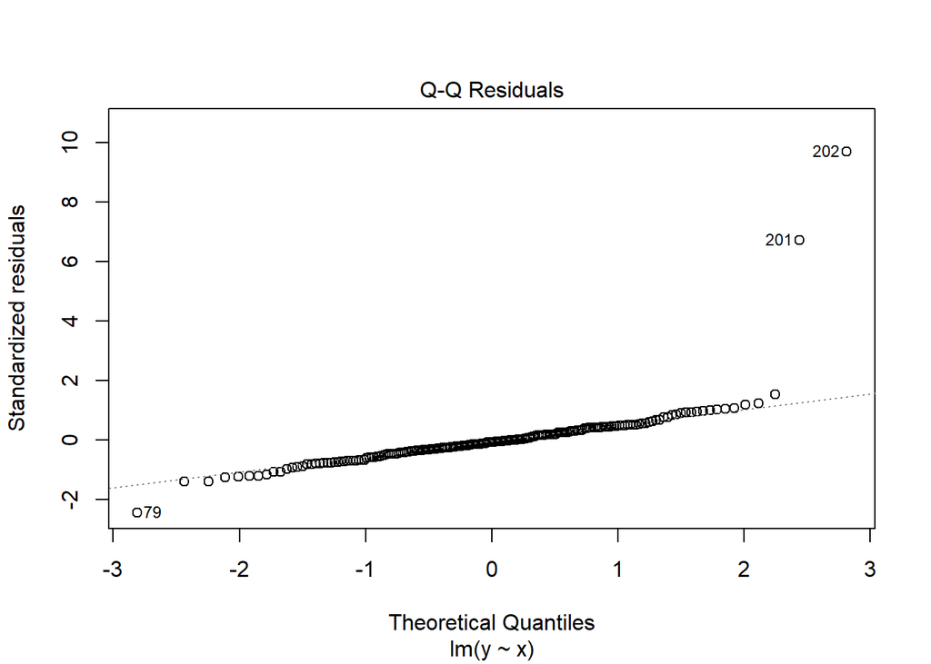

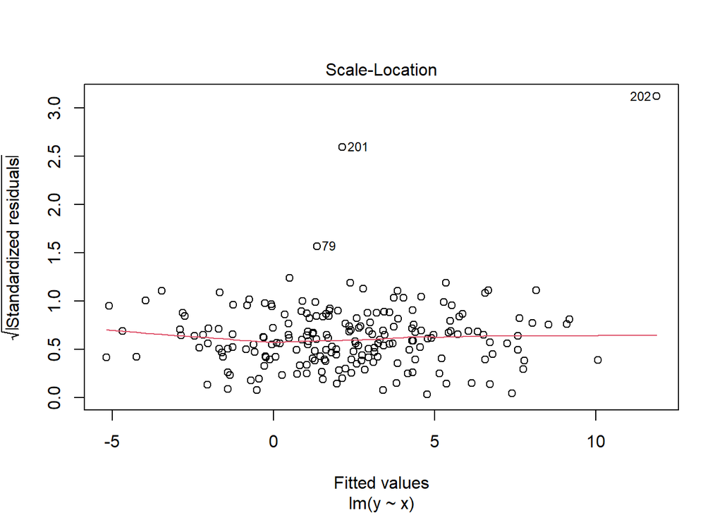

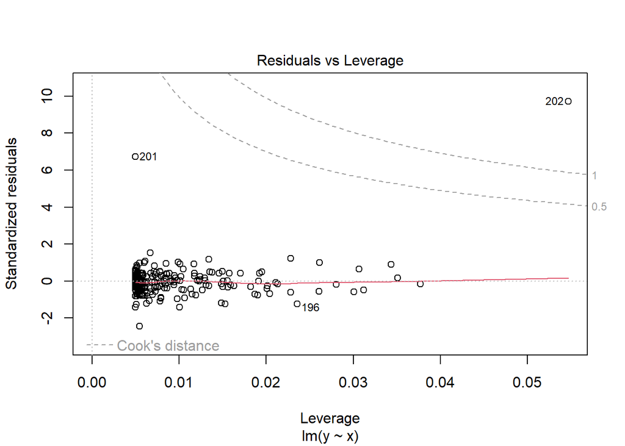

```r
model_out2 <- lm(y~x)
plot(model_out2)
```

The second outlier has high influence (Cook’s distance greater than 1). In fact, you can see the effect of including it in the data set via:

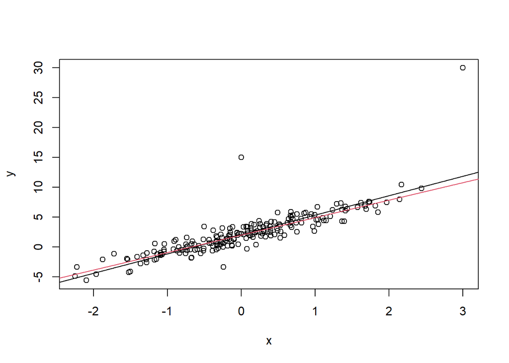

```r
plot(x,y)
abline(coef(model_out2))
abline(coef(model),col=2) #least squares line without the outlier
```

The line of best fit obtained with the (second) outlier included in the data, has a larger slope coefficient than that obtained without the (second) outlier.

## Exercises 2

This exercise concerns the data set `hwages` consisting of 534 observations on 7 variables. We will focus on the following variables:

- `wages` - hourly wage (in dollars). We will treat this as the response.
- `workexp` - work experience in years.
- `education` - schooling in years.
- `sector` - 0 for private and 1 for public (e.g. hospital, school etc).

Read in the data from Andy’s Github page with

```r
hwages <-
   read.csv(file="https://andygolightly.github.io/teaching/MATH43515/hwages.csv")
```

Let’s also explicitly store the columns we will need as separate variables:

```r
data <- hwages
wages <- data$wages #response / dependent variable
workexp <- data$workexp
educ <- data$education
sector <- as.factor(data$sector)
```

1. Plot a histogram of the dependent variable (`wages`). Do you see any skewness? Is this a problem?

**Click for solution**

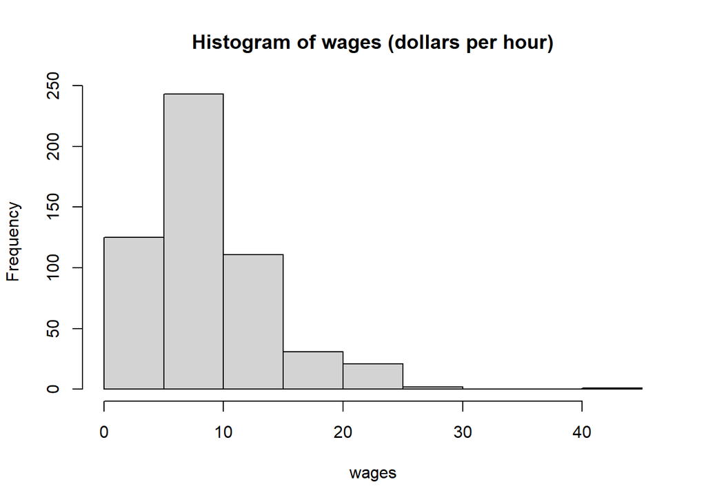

```r
hist(wages,main="Histogram of wages (dollars per hour)")
```

Indeed there is some skewness although this is not necessarily a problem. A skewed dependent variable does not violate any assumptions since we require normality of residuals, not variables.

Let’s transform the response variable via the natural logarithm:

```r
lwages <- log(wages)
```

2. How does a histogram of `lwages` compare to that in part 1?

**Click for solution**

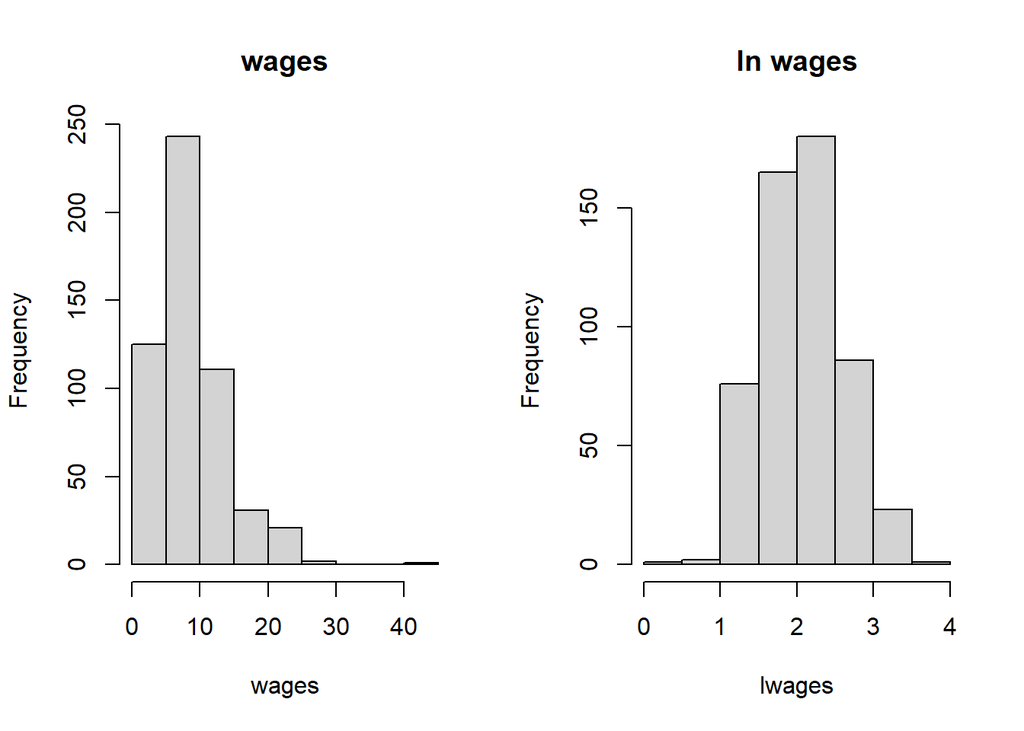

```r
par(mfrow=c(1,2))
hist(wages,main="wages")
hist(lwages,main="ln wages")
```

The right skew appears to be alleviated by the transformation.

3. Denote by $y_i$ the value of the **log wage** for person $i$. Fit the model

$$Y_i = \beta_0 + \beta_1
\textrm{education}_i + \beta_2 \textrm{sector}_i + \epsilon_i, \quad
i=1,\ldots,n$$
with the result stored in `model1`. What do the results suggest for the predicted public sector hourly wage vs private? Hint: use `lm()` and `summary()`. Be careful with the interpretation - recall that the response is the natural logarithm of hourly wage.

**Click for solution**

```r
model1 <- lm(lwages~educ+sector)
summary(model1)
```

```
##
## Call:
## lm(formula = lwages ~ educ + sector)
##
## Residuals:
##      Min       1Q   Median       3Q      Max
## -2.08737 -0.35123  0.03087  0.33134  1.78649
##
## Coefficients:
##              Estimate Std. Error t value Pr(>|t|)
## (Intercept)  1.165192   0.106130  10.979   <2e-16 ***
## educ         0.076848   0.007867   9.768   <2e-16 ***
## sector1     -0.232067   0.041254  -5.625    3e-08 ***
## ---
## Signif. codes:  0 '***' 0.001 '**' 0.01 '*' 0.05 '.' 0.1 ' ' 1
##
## Residual standard error: 0.475 on 531 degrees of freedom
## Multiple R-squared:  0.1928, Adjusted R-squared:  0.1898
## F-statistic: 63.42 on 2 and 531 DF,  p-value: < 2.2e-16
```

We see that the estimate of the variable `sector` is $-0.232$. Hence, with the `educ` variable held constant, the model suggests that average hourly log wages are reduced by $-0.232$ for public sector workers. Hence, actual average hourly wage is reduced by a (multiplicative) factor of $(1-\exp(-0.232))\times 100\%=20\%$.

4. We can set up functions to evaluate the equations of the two lines (one for `sector=0` and one for `sector=1`) as functions of the variable `educ` as follows:

```r
eq1 <- function(educ){coef(model1)[1]+coef(model1)[2]*educ} #private sector
eq2 <- function(educ){coef(model1)[1]+coef(model1)[2]*educ+coef(model1)[3]} #public sector
```

Overlay the fitted line by sector type on the scatterplot of `lwages` against `educ`. (Hint: first set up a vector of `x` values, e.g. using `seq()`, against which to plot the output of `eq1` and `eq2`.)

**Click for solution**

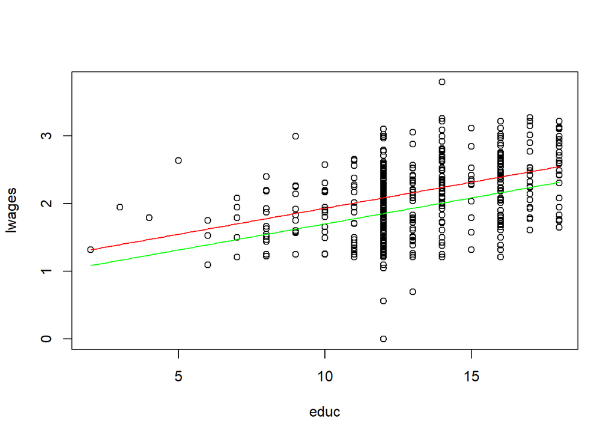

```r
x <- seq(min(educ),max(educ),0.1) #set up educ values at which to evaluate line
plot(educ,lwages)
lines(x,eq1(x),type="l",col="red") #private
lines(x,eq2(x),type="l",col="green") #public
```

5. Add the variable named `workexp` to `model1` (that is, fit the multiple linear regression model with this additional predictor variable). Name the resulting model `model2`.

**Click for solution**

```r
model2 <- lm(lwages~educ+sector+workexp)
```

6. Interpret the coefficients of `model2` in the context of both wage and log wage.

**Click for solution**

```r
summary(model2)
```

```
##
## Call:
## lm(formula = lwages ~ educ + sector + workexp)
##
## Residuals:
##      Min       1Q   Median       3Q      Max
## -2.15504 -0.30764  0.00708  0.30955  1.99176
##
## Coefficients:
##              Estimate Std. Error t value Pr(>|t|)
## (Intercept)  0.674929   0.120510   5.601 3.43e-08 ***
## educ         0.098006   0.008009  12.237  < 2e-16 ***
## sector1     -0.255947   0.039409  -6.495 1.92e-10 ***
## workexp      0.012668   0.001697   7.466 3.42e-13 ***
## ---
## Signif. codes:  0 '***' 0.001 '**' 0.01 '*' 0.05 '.' 0.1 ' ' 1
##
## Residual standard error: 0.4523 on 530 degrees of freedom
## Multiple R-squared:  0.2696, Adjusted R-squared:  0.2655
## F-statistic: 65.22 on 3 and 530 DF,  p-value: < 2.2e-16
```

We have that $b_1=0.098$, $b_2=-0.256$ and $b_3=0.013$. Hence, an additional year of schooling increases average log wage by 0.098 (with the other variables held constant). An additional year of work experience increases log wage by 0.013. The average hourly log wage for public sector workers appears to be 0.256 (log dollars) lower than for private sector workers. Working with log wages makes interpretation difficult. A better interpretation here is to look at the percentage increase or decrease resulting from a unit change in one variable (while keeping the others constant). For example, the percentage increase in average wage resulting from an additional year of schooling is $(\exp(0.098)-1)\times 100\%=10\%$ (with the other variables held constant).

7. What does the adjusted $R^2$ suggest about `model2` compared to `model1`?

**Click for solution**

The adjusted R-squared is 0.2655 for `model2` versus 0.1898 for `model1` suggesting a reasonable improvement in explained variation when moving to `model2`. These values are quite small though; only $27\%$ of the variation in the response is explained by the regression on `educ`, `sector` and `workexp` is not great from a performance perspective!

8. Run the command `anova(model1, model2)`. Which model (`model1` or `model2`) is preferred?

**Click for solution**

```r
anova(model1, model2)
```

|  | Res.Df | RSS | Df | Sum of Sq | F | Pr(>F) |
| --- | --- | --- | --- | --- | --- | --- |
| 1 | 531 | 119.8253 | NA | NA | NA | NA |
| 2 | 530 | 108.4220 | 1 | 11.40337 | 55.74318 | 3.416631e-13 |

We see that the test statistic is large (much bigger than 1) and the p-value is very small (certainly much smaller than 5%) suggesting strong evidence against the null hypothesis that the larger model offers no improvement in fit compared to the simpler model. The conclusion is that the additional `workexp` variable is needed. Note that the p-value is the same as that for testing the significance of the slope coefficient for the `workexp` variable. We’d expect this, as the two models only differ by one covariate (and recall that the t-test answers the question of whether or not a predictor is important GIVEN THAT the other predictors are present).

9. Check the regression assumptions of `model2`.

**Click for solution**

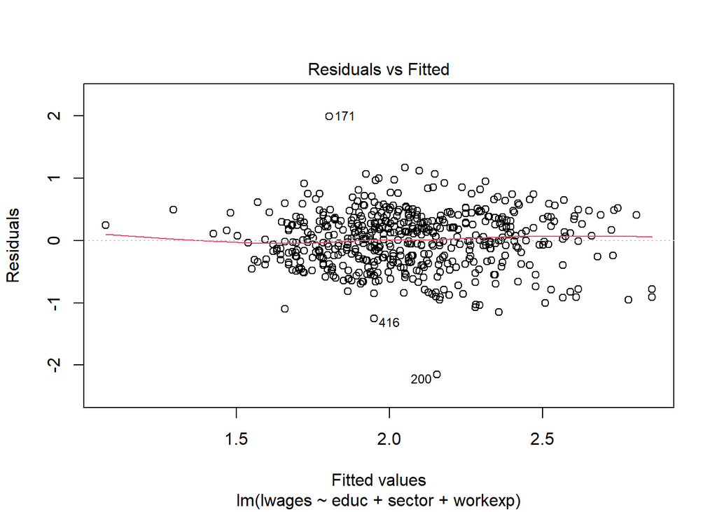

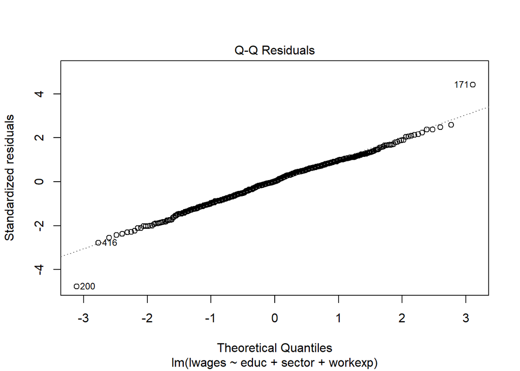

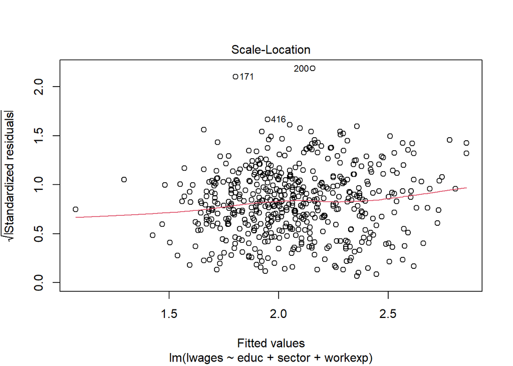

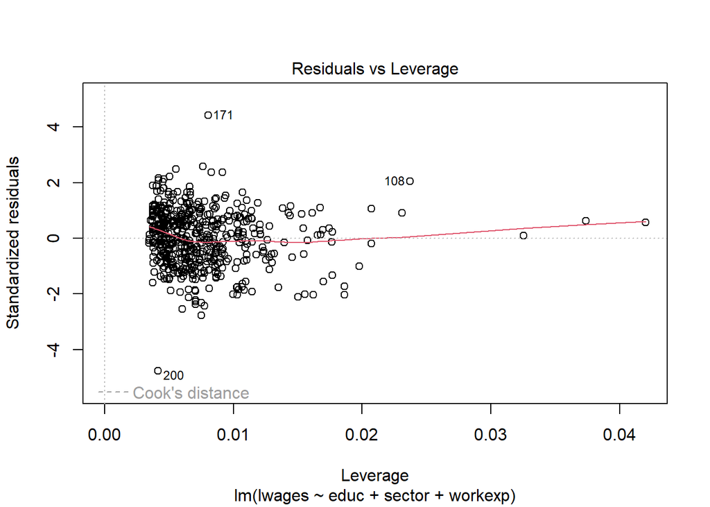

```r
plot(model2)
```

The Q-Q plots suggests that the normality assumption is reasonable. Plots of the residuals against fitted values show no obvious pattern (i.e. no fanning out; the constant variance assumption appears reasonable, and no systematic shape; the linear relationship between log wages and predictors appears reasonable). The last plot indicates some outliers but these do not appear to be of high influence (according to Cook’s distance) so it is not necessary to remove them.

End of lab!